# Locus Leads on the AFR, EAS and AMR Stores (#405)

Published

November 6, 2026

## The question

The EUR sweep (#403) found no (D, W) at which Locus Leads agree with plink2 r² 0.01 clumping closely enough per lead, and its owner’s decision was to judge `n_loci_*` — a per-Analysis count — **by counts**: C1 rank, C2 density against HapMap3, C3 cM against bp-only, written into `counts.criteria` before they were computed. This runs the same sweep on the other ancestries we have a Store and a genotype panel for, each against its own panel and its own map, and answers two predictions of #62’s revision:

1. **Does AFR need a smaller D than EUR?** LD decays faster per cM where effective population size is larger, so one cM leaves less LD in AFR.
2. **Is the AMR map usable?** Admixture creates long-range LD that LD-based maps read as low recombination, so AMR is the least trustworthy map.

The count criteria below are the ones that judge the count; the per-lead rates stay in as diagnostics, as #403 kept them. Each ancestry was swept one after another, on the same grid and the same 1,000,000-row cap, with seed 405 where the EUR sweep used 403.

## The draws

Each draw takes the Analyses a Store assigns that ancestry and measures each one’s Observed Associations at the 5×10⁻⁸ tier. The |z| ≥ 100 and |z| ≥ 38.5 quotas are floors: where the pool has fewer, the draw takes what there is and the record says so (`quota_floors`). Analyses with no Observed Association at the tier cannot be drawn, and an Analysis whose rows are mostly outside the panel is recorded rather than swept.

[output not shown]

The pools, by observed 5×10⁻⁸ rows and largest |z|, and what each quota asked for against what the pool held:

| ancestry | target, asked / in pool | z >= 100, asked / in pool | z >= 38.5, asked / in pool | the pool by stratum |
| --- | --- | --- | --- | --- |
| AFR | 40 / 1329 | 5 / 5 | 5 / 39 | 10k-100k x 38.5-100: 27; 10k-100k x <38.5: 12; 10k-100k x >=100: 2; 1k-10k x 38.5-100: 6; 1k-10k x <38.5: 130; <1k x <38.5: 1148; >=100k x 38.5-100: 1; >=100k x >=100: 3 |
| EAS | 40 / 83 | 5 / 0 | 5 / 0 | <1k x <38.5: 83 |
| AMR | 40 / 813 | 5 / 0 | 5 / 2 | 10k-100k x <38.5: 7; 1k-10k x 38.5-100: 2; 1k-10k x <38.5: 59; <1k x <38.5: 745 |

(EUR’s own record is #403’s and does not carry the floors; its pool held 7,372 Analyses and it drew 40.)

## The count criteria

C1, C2 and C3 are #403’s, unchanged; their wording is in each sweep’s `counts.criteria`.

| ancestry | C1 held at | rho range | C2 held at | C1 and C2 | the point named | the best cM point | C3 holds at |
| --- | --- | --- | --- | --- | --- | --- | --- |
| EUR | 24 of 24 | 0.982 to 0.997 | 20 of 24 | 20 of 24 | bp only / 10 Mb | 2.5 cM / 10 Mb | no W |
| AFR | 4 of 24 | 0.722 to 0.975 | 0 of 24 | 0 of 24 | none | none | 0.25 Mb, 1 Mb, 2.5 Mb, 10 Mb |
| EAS | 24 of 24 | 0.953 to 0.979 | 12 of 24 | 12 of 24 | 1 cM / 1 Mb | 1 cM / 1 Mb | no W |
| AMR | 24 of 24 | 0.966 to 0.990 | 0 of 24 | 0 of 24 | none | none | 10 Mb |

The named points, and what each costs in leads lost to variant density:

| ancestry | point | D | W | rho | median ratio | median \|log2\| | leads lost to density |
| --- | --- | --- | --- | --- | --- | --- | --- |
| EUR | named | bp only | 10 Mb | 0.982 | 0.946 | 0.079 | 4.8% |
| EUR | best cM | 2.5 cM | 10 Mb | 0.986 | 0.900 | 0.152 | 9.3% |
| EAS | named | 1 cM | 1 Mb | 0.953 | 1.000 | 0.000 | 21.2% |
| EAS | best cM | 1 cM | 1 Mb | 0.953 | 1.000 | 0.000 | 21.2% |

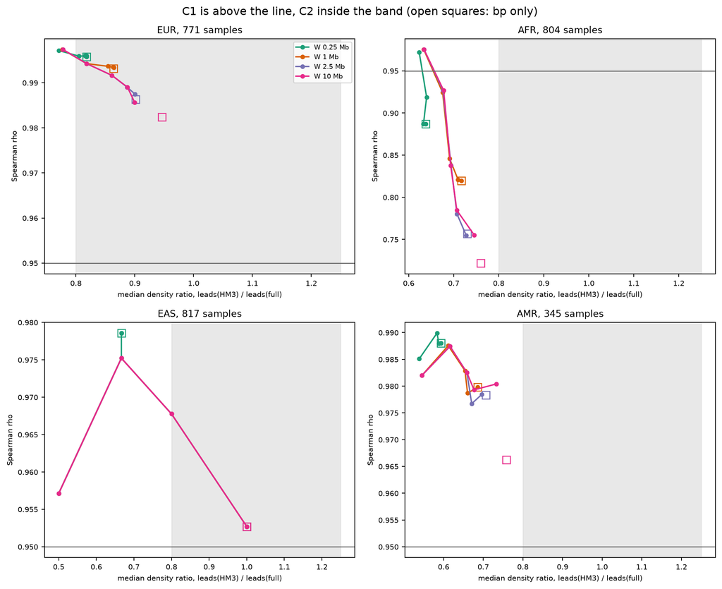

### C3: does cM beat the same W’s bp-only window?

Each cell is the cM point’s Δrho and Δ|log2| against bp-only at the same W, positive being better; the margins are 0.01 and 0.1.

| ancestry | W | C3 holds | D that hold | bp-only rho | Δrho/Δ\|log2\| by D |
| --- | --- | --- | --- | --- | --- |
| EUR | 0.25 Mb | no | - | 0.996 | 0.1: +0.001/-0.086; 0.25: +0.000/-0.023; 0.5: +0.000/-0.005; 1: +0.000/-0.001; 2.5: +0.000/+0.000 |
| EUR | 1 Mb | no | - | 0.993 | 0.1: +0.004/-0.152; 0.25: +0.001/-0.078; 0.5: +0.000/-0.015; 1: +0.000/+0.002; 2.5: +0.000/-0.000 |
| EUR | 2.5 Mb | no | - | 0.986 | 0.1: +0.011/-0.213; 0.25: +0.008/-0.140; 0.5: +0.005/-0.066; 1: +0.003/-0.024; 2.5: +0.001/-0.002 |
| EUR | 10 Mb | no | - | 0.982 | 0.1: +0.015/-0.283; 0.25: +0.012/-0.210; 0.5: +0.009/-0.136; 1: +0.007/-0.093; 2.5: +0.003/-0.073 |
| AFR | 0.25 Mb | yes | 0.1, 0.25 | 0.887 | 0.1: +0.085/-0.033; 0.25: +0.032/+0.004; 0.5: +0.000/-0.012; 1: +0.000/+0.000; 2.5: +0.000/+0.000 |
| AFR | 1 Mb | yes | 0.25, 0.5 | 0.820 | 0.1: +0.156/-0.179; 0.25: +0.105/-0.087; 0.5: +0.026/-0.054; 1: +0.001/-0.015; 2.5: +0.000/+0.000 |
| AFR | 2.5 Mb | yes | 0.5, 1 | 0.757 | 0.1: +0.219/-0.203; 0.25: +0.170/-0.111; 0.5: +0.081/-0.073; 1: +0.024/-0.046; 2.5: -0.002/-0.004 |
| AFR | 10 Mb | yes | 2.5 | 0.722 | 0.1: +0.253/-0.262; 0.25: +0.205/-0.166; 0.5: +0.116/-0.133; 1: +0.063/-0.105; 2.5: +0.033/-0.028 |
| EAS | 0.25 Mb | no | - | 0.979 | 0.1: -0.021/-0.415; 0.25: -0.003/+0.000; 0.5: +0.000/+0.000; 1: +0.000/+0.000; 2.5: +0.000/+0.000 |
| EAS | 1 Mb | no | - | 0.953 | 0.1: +0.004/-1.000; 0.25: +0.023/-0.585; 0.5: +0.015/-0.322; 1: +0.000/+0.000; 2.5: +0.000/+0.000 |
| EAS | 2.5 Mb | no | - | 0.953 | 0.1: +0.004/-1.000; 0.25: +0.023/-0.585; 0.5: +0.015/-0.322; 1: +0.000/+0.000; 2.5: +0.000/+0.000 |
| EAS | 10 Mb | no | - | 0.953 | 0.1: +0.004/-1.000; 0.25: +0.023/-0.585; 0.5: +0.015/-0.322; 1: +0.000/+0.000; 2.5: +0.000/+0.000 |
| AMR | 0.25 Mb | no | - | 0.988 | 0.1: -0.003/-0.140; 0.25: +0.002/-0.024; 0.5: -0.000/-0.012; 1: +0.000/+0.000; 2.5: +0.000/+0.000 |
| AMR | 1 Mb | no | - | 0.980 | 0.1: +0.002/-0.331; 0.25: +0.008/-0.166; 0.5: +0.003/-0.070; 1: -0.001/-0.055; 2.5: +0.000/+0.000 |
| AMR | 2.5 Mb | no | - | 0.978 | 0.1: +0.004/-0.373; 0.25: +0.009/-0.197; 0.5: +0.004/-0.101; 1: -0.002/-0.074; 2.5: +0.000/-0.021 |
| AMR | 10 Mb | yes | 2.5 | 0.966 | 0.1: +0.016/-0.476; 0.25: +0.021/-0.300; 0.5: +0.016/-0.203; 1: +0.013/-0.165; 2.5: +0.014/-0.049 |

## Per-lead diagnostics and chance LD

Kept because #403 kept them, and because they say *where* the two methods disagree. No ancestry’s nearest point meets both tolerances either.

Whether a disagreement straddles a narrow jump in the map is **not assessed** for these three ancestries: the spike sets #402 found are single populations of the EUR mean map, so the sweeps recorded none (`spikes: []`). That key means the question was not put to this data, not that no pair straddles anything — the EAS map keeps two such jumps, listed in the map directory’s README.

The nearest (D, W) by the larger of its two rates, its r² 0.01 rates, the bp-only window beside it, and the chance share of its **within-Analysis index pairs** reaching r² 0.01 — pairs among each Analysis’s clump index variants, so the share moves with how many hits an ancestry has.

| ancestry | nearest D | W | Locus Leads | index variants | spurious | lost | bp-only spurious | bp-only lost | chance r2 >= 0.01 (within-Analysis index pairs) | such pairs |
| --- | --- | --- | --- | --- | --- | --- | --- | --- | --- | --- |
| EUR | 0.1 cM | 2.5 Mb | 23,009 | 21,510 | 32.3% | 27.6% | 5.5% | 64.6% | 1.2% | 13,823,613 |
| AFR | 0.1 cM | 0.25 Mb | 6,422 | 7,176 | 40.4% | 46.7% | 31.2% | 53.0% | 1.5% | 1,342,319 |
| EAS | 0.25 cM | 0.25 Mb | 83 | 83 | 15.7% | 15.7% | 13.8% | 16.9% | 2.2% | 92 |
| AMR | 0.5 cM | 1 Mb | 2,469 | 2,687 | 33.6% | 39.0% | 28.0% | 39.9% | 12.3% | 199,755 |

**Within-Analysis index pairs.** Index variants on different chromosomes are unlinked, so the share of such pairs reaching each r² is a chance share — but it is taken among each Analysis’s own clump index variants, so it depends on how many hits that Analysis has. The share is of pairs with a defined r²; EAS’s rests on 92 pairs.

| ancestry | samples | pairs | r2 undefined | r2 >= 0.001 | r2 >= 0.01 | r2 >= 0.05 | r2 >= 0.1 |
| --- | --- | --- | --- | --- | --- | --- | --- |
| EUR | 771 | 13,823,613 | 9,139 | 42.33% | 1.24% | 0.00% | 0.00% |
| AFR | 804 | 1,342,319 | 0 | 43.84% | 1.55% | 0.00% | 0.00% |
| EAS | 817 | 92 | 0 | 33.70% | 2.17% | 0.00% | 0.00% |
| AMR | 345 | 199,755 | 1,818 | 59.98% | 12.27% | 0.66% | 0.16% |

**The panel’s own chance LD** (`ancestries_chance_ld.json`): the variant pool is the union of the swept Analyses’ shared sets — the panel as the sweeps used it — and both the variants (at most 3,000 of them) and the cross-chromosome pairs (200,000) are drawn with seed 405. This is a property of the panel’s sample size, not of any Analysis’s hit count.

| ancestry | samples | pooled variants | variants used | pairs drawn | r2 undefined | r2 >= 0.001 | r2 >= 0.01 | r2 >= 0.05 | r2 >= 0.1 |
| --- | --- | --- | --- | --- | --- | --- | --- | --- | --- |
| EUR | 771 | 950,809 | 3,000 | 200,000 | 0 | 42.00% | 1.16% | 0.00% | 0.00% |
| AFR | 804 | 140,181 | 3,000 | 200,000 | 0 | 44.30% | 1.70% | 0.01% | 0.00% |
| EAS | 817 | 1,536 | 1,536 | 200,000 | 0 | 41.65% | 1.40% | 0.00% | 0.00% |
| AMR | 345 | 65,168 | 3,000 | 200,000 | 83 | 66.67% | 18.73% | 1.04% | 0.10% |

## The two predictions

D is read at the nearest per-lead point and at the point the counts name:

| ancestry | D at the nearest per-lead point | D at the named count point |
| --- | --- | --- |
| EUR | 0.1 cM | bp only / 10 Mb |
| AFR | 0.1 cM | none |
| EAS | 0.25 cM | 1 cM / 1 Mb |
| AMR | 0.5 cM | none |

**1. Does AFR need a smaller D than EUR? The counts cannot answer it.** AFR names no (D, W) at all: C1 holds at 4 of 24 points and C2 at 0, so nothing is named, and both ancestries’ nearest per-lead point is the smallest D the grid holds, 0.1 cM — a measured D for AFR would be at or below the floor, where the grid cannot look. What is observed beside that: at W 1 Mb, rho is 0.975 for AFR at D 0.1 cM and 0.820 with bp only, against 0.997 and 0.993 for EUR, so AFR’s rank agreement is far more sensitive to D than EUR’s, and C3 holds at 4 of 4 W’s for AFR and 0 for EUR. EUR’s own named point is bp only / 10 Mb and its best cM point 2.5 cM at 10 Mb; AFR’s density ratio peaks at 0.760 against EUR’s 0.946 at the same W. That AFR’s counts are more D-sensitive is consistent with the prediction; a smaller calibrated D is not shown, and a grid below 0.1 cM is the owner’s call. - **AFR**: C1 at 4 of 24 points, C2 at 0, C3 at 4 of 4 W’s. Nearest per-lead point 0.1 cM / 0.25 Mb: 40.4% spurious, 46.7% lost. Within-Analysis index pairs reach r² 0.01 in 1.5% of pairs at 804 samples; the panel’s own chance LD is 1.7%. - **EAS**: C1 at 24 of 24 points, C2 at 12, C3 at 0 of 4 W’s. Nearest per-lead point 0.25 cM / 0.25 Mb: 15.7% spurious, 15.7% lost. Within-Analysis index pairs reach r² 0.01 in 2.2% of pairs at 817 samples; the panel’s own chance LD is 1.4%. - **AMR**: C1 at 24 of 24 points, C2 at 0, C3 at 1 of 4 W’s. Nearest per-lead point 0.5 cM / 1 Mb: 33.6% spurious, 39.0% lost. Within-Analysis index pairs reach r² 0.01 in 12.3% of pairs at 345 samples; the panel’s own chance LD is 18.7%. - **EUR**: C1 at 24 of 24 points, C2 at 20, C3 at 0 of 4 W’s. Nearest per-lead point 0.1 cM / 2.5 Mb: 32.3% spurious, 27.6% lost. Within-Analysis index pairs reach r² 0.01 in 1.2% of pairs at 771 samples; the panel’s own chance LD is 1.2%.

**2. Is the AMR map usable?** For the count it is as good as any other: C1 holds at 24 of 24 points, and rho runs 0.966 to 0.990. What it cannot do is decide D: C2 fails at every point (the density ratio never reaches 0.8), C3 holds at 1 of 4 W’s, and the ground truth itself is weak here — at 345 samples, 18.7% of unlinked pairs reach r² 0.01 by chance in the panel’s own pool, against 1.7% at 804, 1.4% at 817 and 1.2% at 771. A clump count at r² 0.01 is then partly a chance-LD count, so neither the per-lead rates (33.6% spurious, 39.0% lost) nor a D chosen from it can be trusted. What the splits themselves show is admixture’s long LD: at AMR’s nearest point, 86.0% of its spurious splits lie beyond 1 Mb and 45.7% have r² over 0.05, where chance gives 1.0%; for AFR the two shares are 42.2% and 26.3%, and for EUR 25.9% and 35.1%. No cM distance inside W separates a pair like that. Usable as a rank-preserving count; not usable to calibrate D until there is a ground truth that is not chance LD at that sample size and a rule that sees past W.

## The disagreeing pairs

Each sweep writes its both-kinds pair file beside its JSON, with its sha256 in the JSON. Checked here against the JSON’s own summaries:

| ancestry | pair file | rows | sha256 |
| --- | --- | --- | --- |
| AFR | ancestries_afr_sweep_pairs.tsv.gz | 20,428 | 99243f5db5ca31bf… |
| EAS | ancestries_eas_sweep_pairs.tsv.gz | 116 | 0e3c983a1b91ff16… |
| AMR | ancestries_amr_sweep_pairs.tsv.gz | 8,021 | 748e620a6fb38b19… |

## What limits the comparison

| ancestry | swept | below the floor | min shared share | median | max | tier rows swept | chance pairs |
| --- | --- | --- | --- | --- | --- | --- | --- |
| EUR | 37 | 3 | 0.714 | 0.926 | 1.000 | 1,964,596 | 13,823,613 |
| AFR | 26 | 14 | 0.707 | 0.763 | 0.918 | 403,086 | 1,342,319 |
| EAS | 30 | 10 | 0.875 | 0.997 | 1.000 | 3,529 | 92 |
| AMR | 29 | 11 | 0.908 | 0.967 | 1.000 | 178,728 | 199,755 |

A drawn Analysis whose rows are mostly absent from its panel is recorded in the sweep’s `left_out_below_shared_set_floor` and not swept. The floor is 70%; an Analysis just under it loses about a third of its tier rows to variants the panel does not hold.

## Reproduce

Each ancestry’s map, selection and sweep, from the repository root:

```bash
for a in AFR EAS AMR; do
  pixi run -e dev python -m prototypes.locus_leads build-map \
      --archive /data/opengwasdb/reference/genetic-map/pyrho-1kg-hg38/original/hg38_maps.tar.gz \
      --ancestry $a --output /data/opengwasdb/reference/genetic-map/pyrho-1kg-hg38/$a.tsv.gz
done
pixi run -e dev python -m prototypes.locus_leads select --stores /data/opengwasdb/stores \
    --seed 405 --ancestry AFR --output docs/benchmark-output/locus_leads/ancestries_afr_selection.json
pixi run -e dev python -m prototypes.locus_leads sweep \
    --selection docs/benchmark-output/locus_leads/ancestries_afr_selection.json \
    --stores-dir /data/opengwasdb/stores \
    --genetic-map /data/opengwasdb/reference/genetic-map/pyrho-1kg-hg38/AFR.tsv.gz \
    --panel /data/opengwasdb/reference/hgdp1kgp-hg38/pgen/AFR \
    --hm3 /data/opengwasdb/reference/hapmap3-hg38/hm3.grch38.alid.txt \
    --spikes none --work-dir <scratch directory> \
    --output docs/benchmark-output/locus_leads/ancestries_afr_sweep.json
```

EAS and AMR repeat the last two commands with their own name, map and panel: EAS uses `/data/opengwasdb/reference/hgdp1kgp-hg38/pgen/EAS` and AMR `/data/opengwasdb/reference/hgdp1kgp-hg38-amr/pgen/AMR`. The EUR sweep and its selection are #403’s; `eur_sweep.qmd` renders them.